# Electric_field

## 12.4 Other important types of capacitors

Spherical capacitor

Cylindrical capacitor

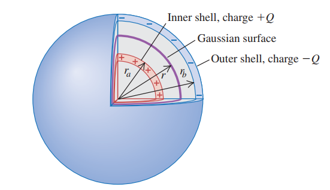

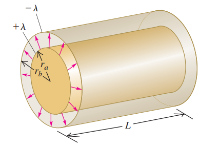

$C=4 \pi \epsilon_{0} \frac{r_{a} r_{b}}{r_{b}-r_{a}}$

$\frac{C}{L}=\frac{2 \pi \epsilon_{0}}{\ln \left(r_{b} / r_{a}\right)}$

See derivation on Sears-Zemansky's chapter 24.

## 12.5 Potential energy of a capacitor

For a given voltage, the work necessary to transfer an infinitesimal charge is $dW=V dq$, so $V dq=\frac{q dq}{C}$ in view of the definition of capacitance (remember, the capacitance $C$ does not change during the charging process, as it only depends on the physical characteristics of the capacitor). Thus

$$W=\int_{0}^{W} d W=\frac{1}{C} \int_{0}^{Q} q d q=\frac{Q^{2}}{2 C}$$

If we define the **potential energy** of an uncharged capacitor to be zero, then $U=W$ and

| $$U=\frac{Q^{2}}{2 C}=\frac{1}{2} C V^{2}=\frac{1}{2} Q V$$ |
| --- |

The **energy density** $u$, defined as energy per unit volume is then

$$u=\frac{\frac{1}{2} C V^{2}}{A d}=\frac{1}{2} \epsilon_{0} E^{2}$$

## 12.6 Dielectrics in capacitors

In practice, dielectrics contain dielectrics between the plates. This gives mechanical support for the whole configuration. Additionally, it increases the capacitance due to polarization: the electric field induces an opposite electric field inside the dielectric, which eventually decreases the voltage $V$ while keeping the charge $Q$ constant, thereby increasing the capacitance.

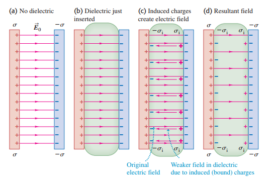

All our previous expressions remain the same by replacing $\epsilon_0\rightarrow\epsilon$

$$E=\sigma_{\mathrm{net}} / \epsilon_{0}=\frac{\sigma-\sigma_{\mathrm{i}}}{\epsilon_{0}}=\frac{\sigma}{\epsilon}$$$$C=\epsilon_{r} C_{0}=\epsilon \epsilon_{0} \frac{A}{d}=\epsilon \frac{A}{d}$$$$u=\frac{1}{2} \epsilon E^{2}$$

## 12.7 Dielectric breakdown

No real dielectric remains an insulator for any electric field. High electric fields ionize the material, allowing conduction of charge: this is known as **dielectric breakdown**, and the magnitude of the field at which it occurs is the **dielectric strength** $E_m$. For dry air $E_m=3\times10^6 V/m$.

## 12.8 Commercial capacitors

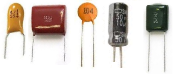

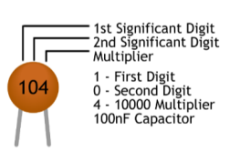

See description of each type [here](http://www.learningaboutelectronics.com/Articles/Types-of-capacitors)

```python
## Capacitors in practice
YouTubeVideo('X4EUwTwZ110')
```

[video not shown]